```python
import numpy as np

# Set up matplotlib and use a nicer set of plot parameters
%config InlineBackend.rc = {}
import matplotlib
matplotlib.rc_file("../../templates/matplotlibrc")
import matplotlib.pyplot as plt
%matplotlib inline
```

The following line is needed to download the example FITS files used here.

```python
from astropy.utils.data import download_file
```

# Viewing and manipulating FITS images

FITS files are the standard format for all astronomical data.

See details on astropy's FITS module here: https://astropy.readthedocs.org/en/latest/io/fits/index.html

```python
from astropy.io import fits
# import pyfits
```

```python
image_file = download_file('http://data.astropy.org/tutorials/FITS-images/HorseHead.fits', cache=True )
```

## Opening FITS files and loading the image data

I will open the FITS file and find out what it contains.

```python
hdu_list = fits.open(image_file)
hdu_list.info()
```

```
Filename: /Users/adam/.astropy/cache/download/2c9202ae878ecfcb60878ceb63837f5f
No.    Name         Type      Cards   Dimensions   Format
0    PRIMARY     PrimaryHDU     161   (891, 893)   int16
1    er.mask     TableHDU        25   1600R x 4C   [F6.2, F6.2, F6.2, F6.2]
```

Generally the image information is located in the `PRIMARY` block. The blocks are numbered and can be accessed by indexing `hdu_list`.

```python
image_data = hdu_list[0].data
# image_data = hdu_list['PRIMARY'].data
```

You data is now stored as a 2-D numpy array. Want to know the dimensions of the image? Just look at the `shape` of the array.

```python
print(type(image_data))
print(image_data.shape)
```

```
<type 'numpy.ndarray'>
(893, 891)
```

The `Header` is also an important component. The info above tells us it has 161 cards:

```python
header = hdu_list['PRIMARY'].header
```

```python
header
```

```
SIMPLE  =                    T /FITS: Compliance
BITPIX  =                   16 /FITS: I*2 Data
NAXIS   =                    2 /FITS: 2-D Image Data
NAXIS1  =                  891 /FITS: X Dimension
NAXIS2  =                  893 /FITS: Y Dimension
EXTEND  =                    T /FITS: File can contain extensions
DATE    = '2014-01-09        '  /FITS: Creation Date
ORIGIN  = 'STScI/MAST'         /GSSS: STScI Digitized Sky Survey
SURVEY  = 'SERC-ER '           /GSSS: Sky Survey
REGION  = 'ER768   '           /GSSS: Region Name
PLATEID = 'A0JP    '           /GSSS: Plate ID
SCANNUM = '01      '           /GSSS: Scan Number
DSCNDNUM= '00      '           /GSSS: Descendant Number
TELESCID=                    4 /GSSS: Telescope ID
BANDPASS=                   36 /GSSS: Bandpass Code
COPYRGHT= 'AAO/ROE '           /GSSS: Copyright Holder
SITELAT =              -31.277 /Observatory: Latitude
SITELONG=              210.934 /Observatory: Longitude
TELESCOP= 'UK Schmidt - Doubl' /Observatory: Telescope
INSTRUME= 'Photographic Plate' /Detector: Photographic Plate
EMULSION= 'IIIaF   '           /Detector: Emulsion
FILTER  = 'OG590   '           /Detector: Filter
PLTSCALE=                67.20 /Detector: Plate Scale arcsec per mm
PLTSIZEX=              355.000 /Detector: Plate X Dimension mm
PLTSIZEY=              355.000 /Detector: Plate Y Dimension mm
PLATERA =        85.5994550000 /Observation: Field centre RA degrees
PLATEDEC=       -4.94660910000 /Observation: Field centre Dec degrees
PLTLABEL= 'OR14052 '           /Observation: Plate Label
DATE-OBS= '1990-12-22T13:49:00' /Observation: Date/Time
EXPOSURE=                 65.0 /Observation: Exposure Minutes
PLTGRADE= 'AD2     '           /Observation: Plate Grade
OBSHA   =             0.158333 /Observation: Hour Angle
OBSZD   =              26.3715 /Observation: Zenith Distance
AIRMASS =              1.11587 /Observation: Airmass
REFBETA =        66.3196420000 /Observation: Refraction Coeff
REFBETAP=     -0.0820000000000 /Observation: Refraction Coeff
REFK1   =        6423.52290000 /Observation: Refraction Coeff
REFK2   =       -102122.550000 /Observation: Refraction Coeff
CNPIX1  =                12237 /Scan: X Corner
CNPIX2  =                19965 /Scan: Y Corner
```

[output cut: 106 more lines]

```
CTYPE2  = 'DEC--TAN          ' /GetImage: Dec-Gnomic projection
CRPIX2  =           447.000000 /GetImage: Y reference pixel
CRVAL2  =            -2.458265 /GetImage: Dec of reference pixel
CUNIT2  = 'deg               ' /Getimage: degrees
CD1_1   =        -0.0002802651 /GetImage: rotation matrix coefficient
CD1_2   =         0.0000003159 /GetImage: rotation matrix coefficient
CD2_1   =         0.0000002767 /GetImage: rotation matrix coefficient
CD2_2   =         0.0002798187 /GetImage: rotation matrix coefficient
OBJECT  = 'data              ' /GetImage: Requested Object Name
DATAMIN =                 3759 /GetImage: Minimum returned pixel value
DATAMAX =                22918 /GetImage: Maximum returned pixel value
OBJCTRA = '05 41 06.000      ' /GetImage: Requested Right Ascension (J2000)
OBJCTDEC= '-02 27 30.00      ' /GetImage: Requested Declination (J2000)
OBJCTX  =             12682.48 /GetImage: Requested X on plate (pixels)
OBJCTY  =             20411.37 /GetImage: Requested Y on plate (pixels)
```

### SHORTCUT

If you don't need to examine the FITS header, you can call `fits.getdata` to bypass the previous steps.

```python
image_data = fits.getdata(image_file)
print(type(image_data))
print(image_data.shape)
```

```
<type 'numpy.ndarray'>
(893, 891)
```

Similarly, if you only want the header, you can use `fits.getheader`:

```python
header = fits.getheader(image_file)
```

## Viewing the image data and getting basic statistics

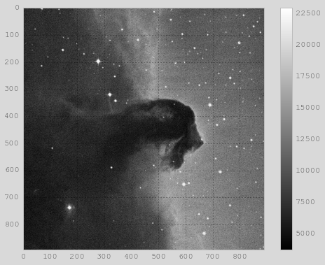

```python
plt.imshow(image_data, cmap='gray')
plt.colorbar()

# To see more color maps
# http://wiki.scipy.org/Cookbook/Matplotlib/Show_colormaps
```

Let's get some basic statistics about our image. If your image contained NaNs, you'd use `np.nanmin` etc below

```python
print('Min:', np.min(image_data))
print('Max:', np.max(image_data))
print('Mean:', np.mean(image_data))
print('Stdev:', np.std(image_data))
```

```
('Min:', 3759)
('Max:', 22918)
('Mean:', 9831.4816762875744)
('Stdev:', 3032.3927542049046)
```

### Plotting a histogram

To make a histogram with `matplotlib.pyplot.hist()`, I need to cast the data from a 2-D to array to something one dimensional.

In this case, I am using the iterable python object `img_data.flat`.

```python
print(type(image_data.flat))
```

```
<type 'numpy.flatiter'>
```

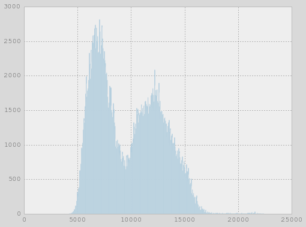

```python
NBINS = 1000
histogram = plt.hist(image_data.flat, NBINS)
```

### Displaying the image with a logarithmic scale

Want to use a logarithmic color scale? To do so we need to load the `LogNorm` object from `matplotlib`.

```python
from matplotlib.colors import LogNorm
```

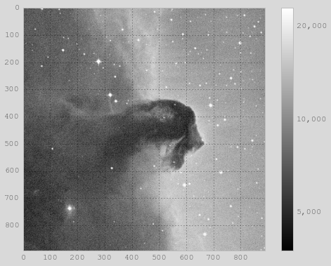

```python
plt.imshow(image_data, cmap='gray', norm=LogNorm())

# I chose the tick marks based on the histogram above
cbar = plt.colorbar(ticks=[5.e3,1.e4,2.e4])
cbar.ax.set_yticklabels(['5,000','10,000','20,000'])
```

## Basic image math: image stacking

You can perform math with the image data like any other numpy array. In this particular example, I will stack several images of M13 taken with a ~10'' telescope.

I open a series of FITS files and store the data in a list, which I've named `image_concat`.

```python
url_template = 'http://data.astropy.org/tutorials/FITS-images/M13_blue_000{0}.fits'
image_list = [download_file(url_template.format(n), cache=True)
              for n in ('1','2','3','4','5')]

# The long way
image_concat = []
for image in image_list:
    image_concat.append(fits.getdata(image))

# The short way
#image_concat = [ fits.getdata(image) for image in IMAGE_LIST ]
```

Now I'll stack the images by averaging my concatenated list.

```python
# The long way - slow, but clear
#final_image = np.zeros(shape=image_concat[0].shape)
#
#for image in image_concat:
#    final_image += image
# final_image /= len(image_concat)

# The short way: numpy will turn your list of images into a 'cube'
# with axis=0 being the shortest (stacked) axis
final_image = np.mean(image_concat, axis=0)
```

I'm going to show the image, but I want to decide on the best stretch. To do so I'll plot a histogram of the data.

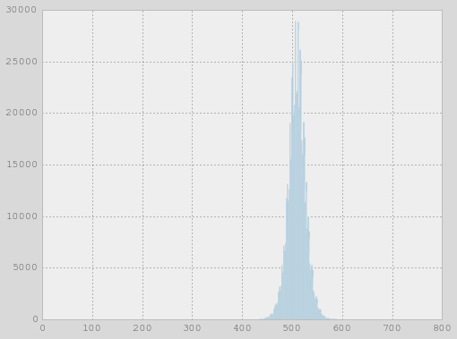

```python
image_hist = plt.hist(final_image.flat, 1000)
```

I'll use the keywords `vmin` and `vmax` to set limits on the color scaling for `imshow`.

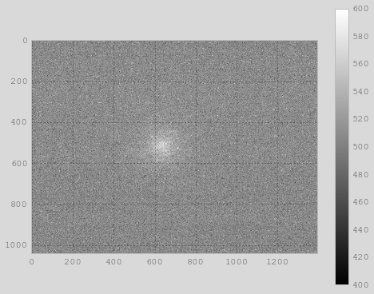

```python
plt.imshow(final_image, cmap='gray', vmin=400, vmax=600)
plt.colorbar()
```

## Writing image data to a FITS file

This is easy to do with the `writeto()` method.

You will receive an error if the file you are trying to write already exists. That's why I've set `clobber=True`.

Most tools in the `astropy` and python ecosystem use the keyword `overwrite` instead of `clobber`; `clobber` is inherited from IRAF.

```python
outfile = 'stacked_M13_blue.fits'

hdu = fits.PrimaryHDU(final_image)
hdu.writeto(outfile, clobber=True)
```

# Using the world coordinate system

"World coordinates" refer to RA/Dec or Galactic latitude/longitude.

The full documentation is available at: http://astropy.readthedocs.org/en/latest/wcs/

```python
from astropy import wcs
```

Step 1. Create a `WCS` object

```python
mywcs = wcs.WCS(header)
```

The most important tools related to a WCS are the conversion from pixels -> wcs and wcs -> pixels, accomplished with `WCS.wcs_pix2world` and `WCS.wcs_world2pix`.

The syntax is cumbersome for converting a single pixel:

```python
xpix, ypix = [50,100]
# The '0' indicates that the pixels are indexed starting at 0, the python/c convention
# You can also use '1', which indicates the FITS/IRAF/FORTRAN convention
(ra,dec), = mywcs.wcs_pix2world([[xpix,ypix]], 0)
print(ra,dec)
```

```
(85.385675186882054, -2.5551867109375919)
```

But convenient for converting an array of pixels:

```python
pix_coords = [(20,30), (50,10), (500,200)]
world_coords = mywcs.wcs_pix2world(pix_coords, 0)
print(world_coords)
```

```
[[ 85.39407108  -2.57478146]
 [ 85.38564882  -2.58037026]
 [ 85.25946264  -2.52708506]]
```

The coordinates can be readily converted to astropy coordinates:

```python
from astropy import coordinates
from astropy import units as u
my_coords = coordinates.SkyCoord(world_coords*u.deg, frame='fk5')
print(my_coords)
print(my_coords.to_string(style='hmsdms'))
```

```
<SkyCoord (FK5): equinox=J2000.000, (ra, dec) in deg
    [(85.39407107595326, -2.574781460695727),
     (85.38564881637622, -2.580370256991026),
     (85.25946263858953, -2.5270850561642217)]>
[u'05h41m34.5771s -02d34m29.2133s', u'05h41m32.5557s -02d34m49.3329s', u'05h41m02.271s -02d31m37.5062s']
```

You can also use WCS to get pixel coordinates for overplotting sources.

```python
horsehead = coordinates.SkyCoord.from_name('Horsehead Nebula')
print(horsehead)
```

```
<SkyCoord (ICRS): ra=85.24583 deg, dec=-2.45833 deg>
```

```python
(hxpix,hypix), = mywcs.wcs_world2pix([(horsehead.ra.deg,
                                       horsehead.dec.deg)],0)
print(hxpix,hypix)
```

```
(548.87693013963485, 445.66385271710652)
```

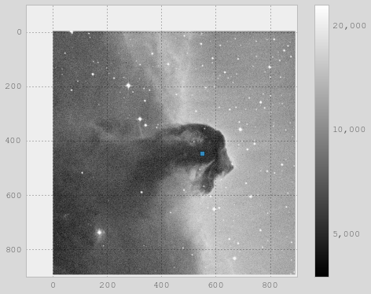

```python
plt.imshow(image_data, cmap='gray', norm=LogNorm())

# I chose the tick marks based on the histogram above
cbar = plt.colorbar(ticks=[5.e3,1.e4,2.e4])
cbar.ax.set_yticklabels(['5,000','10,000','20,000'])
plt.plot(hxpix, hypix, 's')
```

You can also create an HDU 'from scratch', but with a WCS header:

```python
myhdu = fits.PrimaryHDU(data=image_data, header=mywcs.to_header())
```

# Plotting the world coordinate system

Plotting using WCS is a more complicated task and should be left to specialized tools:

- http://wcsaxes.rtfd.org/
- http://aplpy.github.io/

```
INFO:astropy:Auto-setting vmin to  3.634e+03
INFO:astropy:Auto-setting vmax to  1.940e+04
```

```
INFO: Auto-setting vmin to  3.634e+03 [aplpy.core]
INFO: Auto-setting vmax to  1.940e+04 [aplpy.core]
```

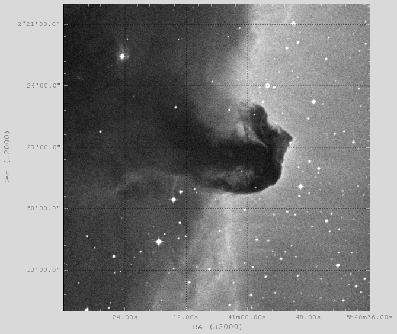

```python
import aplpy
F = aplpy.FITSFigure(hdu_list[0], figure=plt.figure(1))
F.show_grayscale()
# Can use world coordinates directly
F.show_markers(horsehead.ra.deg, horsehead.dec.deg)
```

```python
from wcsaxes import WCSAxes

fig = plt.figure()
ax = WCSAxes(fig, [0.1, 0.1, 0.8, 0.8], wcs=mywcs)
fig.add_axes(ax)  # note that the axes have to be added to the figure
ax.imshow(image_data, origin='lower')
```